# Stats-Project

Christopher Wallis, Adam Raddant

2025-04-01

### **Dataset**

The following is a data set gathered using environmental tracking websites and contains data on the the meteorologic data in the state of Minnesota as well as the CO2 levels in the atmosphere during the corresponding month and year.

Year-  
This is the year for the sample.

Month-  
This is the month for the sample.

Precipitation-  
This is the amount of rainfall in inches.

Average Temp-  
This is the average temp during the month for the corresponding sample. This is measured in Celsius.

CO2-  
This is the average CO2 concentration for the corresponding time sample. This is measured in ppm (parts per million).

### **Setting Up The Dataset**

```r
environmentalData <- read.csv("StatsProject-Data.csv")

head(environmentalData)
```

```
##   Year Month Precipitation Average.Temp    CO2
## 1 1979     1          21.4       -16.68 336.56
## 2 1979     2          38.2       -12.72 337.29
## 3 1979     3          71.3        -2.64 337.88
## 4 1979     4          19.7         5.60 338.32
## 5 1979     5         106.9        12.57 338.26
## 6 1979     6         172.2        19.07 337.38
```

```r
environmentalDataYearly <- environmentalData %>%
  group_by(Year) %>%
  summarize(
    Avg_Prec = mean(Precipitation, na.rm = TRUE),
    Avg_Temp = mean(Average.Temp, na.rm = TRUE),
    Avg_CO2 = mean(CO2, na.rm = TRUE))

head(environmentalDataYearly)
```

```
## # A tibble: 6 × 4
##    Year Avg_Prec Avg_Temp Avg_CO2
##   <int>    <dbl>    <dbl>   <dbl>
## 1  1979     70.8     5.85    337.
## 2  1980     51.8     7.49    339.
## 3  1981     63.0     8.26    340.
## 4  1982     61.8     6.78    341.
## 5  1983     68.5     7.66    343.
## 6  1984     71.9     7.84    344.
```

```r
averagedByMonthData <- environmentalData %>%
  group_by(Month) %>%
  summarize(
    Avg_Prec = mean(Precipitation, na.rm = TRUE),
    Avg_Temp = mean(Average.Temp, na.rm = TRUE),
    Avg_CO2 = mean(CO2, na.rm = TRUE))

averagedByMonthData
```

```
## # A tibble: 12 × 4
##    Month Avg_Prec Avg_Temp Avg_CO2
##    <int>    <dbl>    <dbl>   <dbl>
##  1     1     16.3   -9.18     375.
##  2     2     18.8   -6.92     375.
##  3     3     43.1    0.135    376.
##  4     4     72.9    8.06     376.
##  5     5    102.    15.2      376.
##  6     6    115.    20.5      375.
##  7     7    111.    22.9      374.
##  8     8    117.    21.6      372.
##  9     9     80.4   17.2      373.
## 10    10     67.0    9.65     374.
## 11    11     37.1    1.10     375.
## 12    12     26.7   -6.28     376.
```

### **Examining The Data Through Plots**

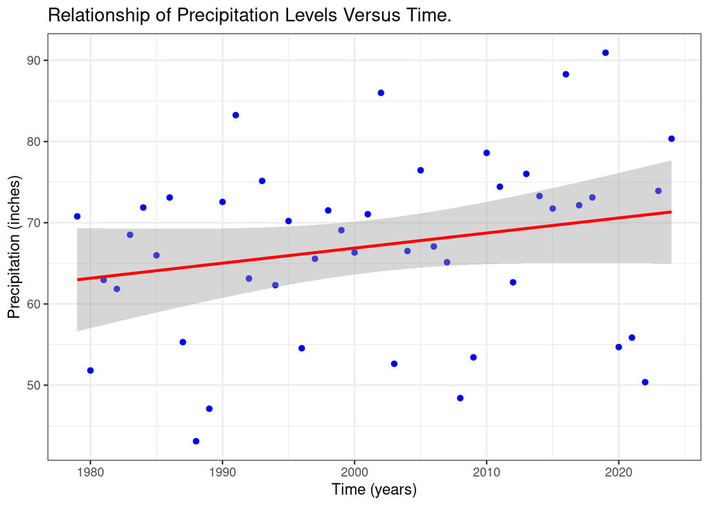

```r
ggplot(data = environmentalDataYearly, aes(x = Year, y = Avg_Prec)) +
  geom_point(color = "blue") +
  geom_smooth(method = "lm", color = "red") +
  theme_bw() +
  labs(title = "Relationship of Precipitation Levels Versus Time.", x = "Time (years)", y = "Precipitation (inches)")
```

```r
cor(environmentalDataYearly$Year, environmentalDataYearly$Avg_Prec)
```

```
## [1] 0.2257339
```

This graph tells us that the precipitation doesn’t really take much of a noticeable increase or decrease over time in the state of Minnesota. However, you can just barely notice a very slight increase in average precipitation as time goes on if you look hard enough. The red regression line also helps visualize the change in precipitation over time.

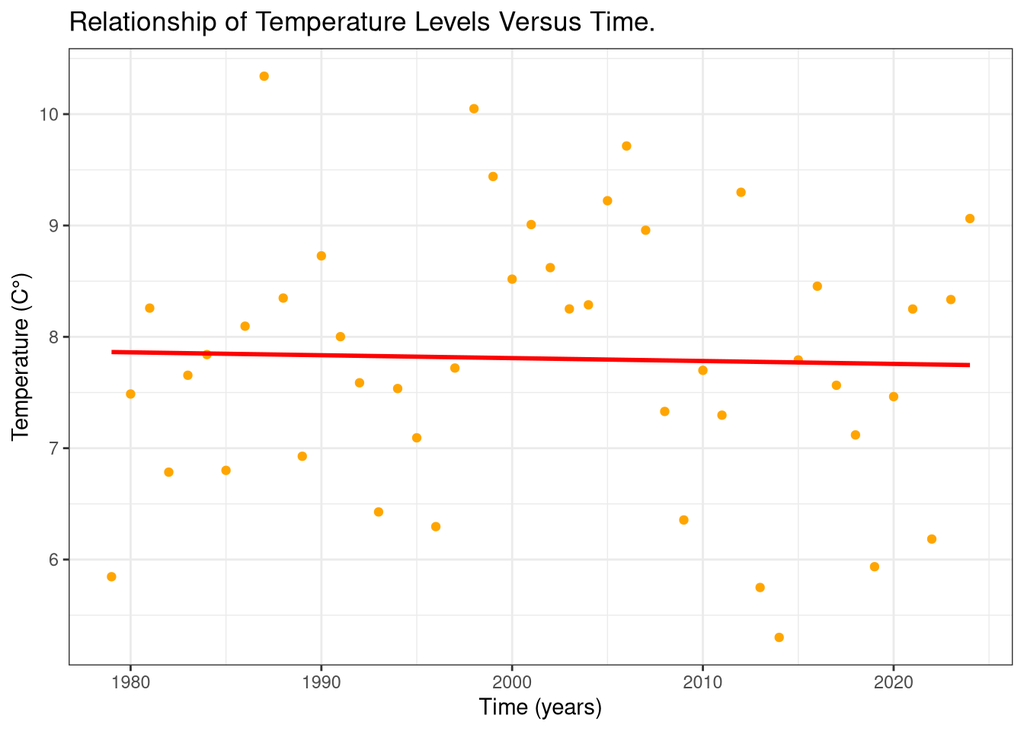

```r
ggplot(data = environmentalDataYearly, aes(x = Year, y = Avg_Temp)) +
  geom_point(color = "orange") +
  geom_smooth(method = "lm", se = FALSE, color = "red") +
  theme_bw() +
  labs(title = "Relationship of Temperature Levels Versus Time.", x = "Time (years)", y = "Temperature (C°)")
```

```r
cor(environmentalDataYearly$Year, environmentalDataYearly$Avg_Temp)
```

```
## [1] -0.02971956
```

This graph tells us that the average temperature doesn’t take a noticeable increase or decrease in the state of Minnesota as time goes on.

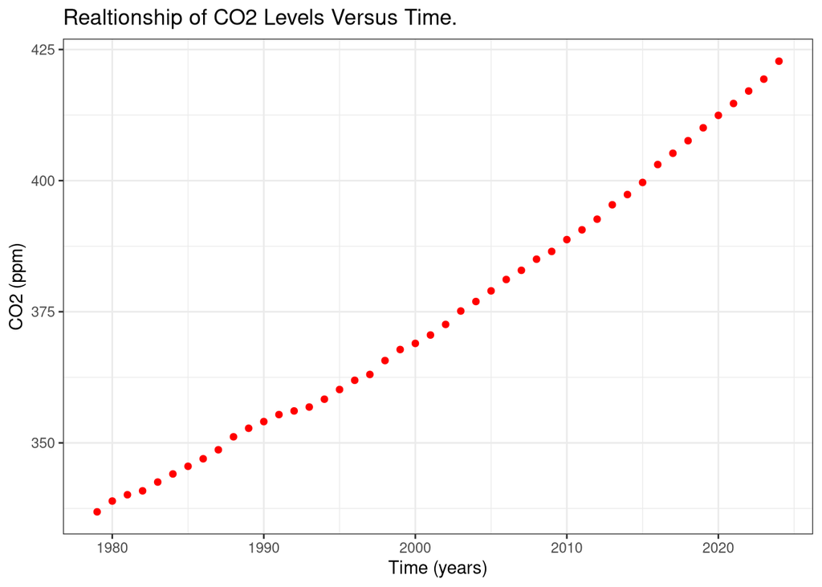

```r
ggplot(data = environmentalDataYearly, aes(x = Year, y = Avg_CO2)) +
  geom_point(color = "red") +
  theme_bw() +
  labs(title = "Realtionship of CO2 Levels Versus Time.", x = "Time (years)", y = "CO2 (ppm)")
```

This graph tells us that there’s a very strong linear relationship of the increase of CO2 in the atmosphere as time goes on. It’s important to note that this information doesn’t tell us much more than that but we can speculate the reasons behind it.

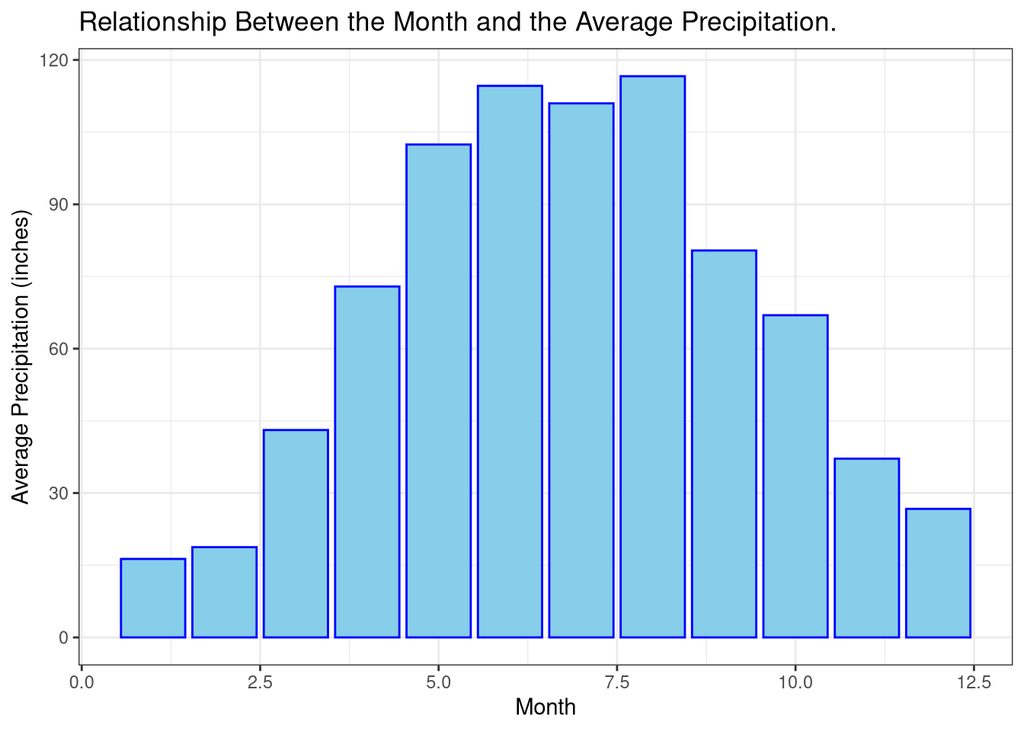

```r
ggplot(data = averagedByMonthData, aes(x = Month, y = Avg_Prec)) +
  geom_bar(stat = "identity", color ="blue", fill =
  "skyblue") +
  theme_bw() +
  labs(title = "Relationship Between the Month and the Average Precipitation.", x = "Month", y = "Average Precipitation (inches)")
```

This graph tells us that during the summer months there is a considerable amount of more precipitation than during the cold months in the year in the state of Minnesota.

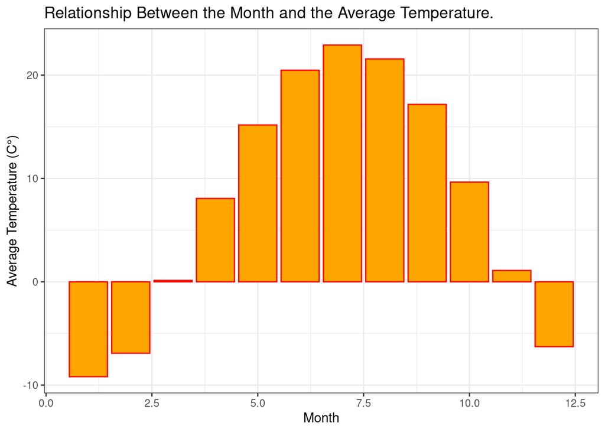

```r
ggplot(data = averagedByMonthData, aes(x = Month, y = Avg_Temp)) +
  geom_bar(stat = "identity", color ="red", fill =
  "orange") +
  theme_bw() +
  labs(title = "Relationship Between the Month and the Average Temperature.", x = "Month", y = "Average Temperature (C°)")
```

This graph tells us that the average temperatures during the summer months are much hotter than during the cold months in the state of Minnesota. This checks out from our own common sense.

### **Using Linear Regression**

```r
CO2_mod <- lm(Avg_CO2 ~ Year, data
    = environmentalDataYearly)

get_regression_table(CO2_mod)
```

```
## # A tibble: 2 × 7
##   term      estimate std_error statistic p_value lower_ci upper_ci
##   <chr>        <dbl>     <dbl>     <dbl>   <dbl>    <dbl>    <dbl>
## 1 intercept -3370.      58.5       -57.7       0 -3488.   -3253.
## 2 Year          1.87     0.029      64.1       0     1.81     1.93
```

```r
CO22_mod <- lm(Avg_CO2 ~ Year + Avg_Prec, data =
    environmentalDataYearly)

get_regression_table(CO22_mod)
```

```
## # A tibble: 3 × 7
##   term       estimate std_error statistic p_value  lower_ci  upper_ci
##   <chr>         <dbl>     <dbl>     <dbl>   <dbl>     <dbl>     <dbl>
## 1 intercept -3375.       60.1     -56.2     0     -3496.    -3254.
## 2 Year          1.87      0.03     61.9     0         1.81      1.94
## 3 Avg_Prec     -0.015     0.037    -0.405   0.687    -0.089     0.059
```

Using this data we can tell that the CO2 hasn’t always increased at this rate, due to the fact that you can’t really have a negative CO2 level. This lets us guess that maybe something recent in history has caused the increase in CO2 that we see today.

```r
prec_mod <- lm(Avg_Prec ~ Year, data =
    environmentalDataYearly)

get_regression_table(prec_mod)
```

```
## # A tibble: 2 × 7
##   term      estimate std_error statistic p_value lower_ci upper_ci
##   <chr>        <dbl>     <dbl>     <dbl>   <dbl>    <dbl>    <dbl>
## 1 intercept -304.      242.        -1.26   0.215 -791.     183.
## 2 Year         0.185     0.121      1.54   0.131   -0.058    0.429
```

```r
prec2_mod <- lm(Avg_Prec ~ Year + Avg_CO2, data =
    environmentalDataYearly)

get_regression_table(prec2_mod)
```

```
## # A tibble: 3 × 7
##   term       estimate std_error statistic p_value lower_ci upper_ci
##   <chr>         <dbl>     <dbl>     <dbl>   <dbl>    <dbl>    <dbl>
## 1 intercept -1163.     2134.       -0.545   0.589 -5466.    3140.
## 2 Year          0.662     1.18      0.56    0.579    -1.72     3.05
## 3 Avg_CO2      -0.255     0.629    -0.405   0.687    -1.52     1.01
```

Once again, this linear regression model tells us that we can not blindly follow this data. The regression table tells us that there is a negative intercept which means that according to the data, in 0 CE there was an average of -304 inches of rain that year. Obviously this makes no sense because you can not have a negative rain amount.

### **Mean Standard Error and Root Mean Standard Error**

```r
get_regression_points(prec_mod) %>%
  mutate(sq_residuals = residual^2) %>%
  summarise(mse = mean(sq_residuals), rmse = sqrt(mean(sq_residuals)))
```

```
## # A tibble: 1 × 2
##     mse  rmse
##   <dbl> <dbl>
## 1  113.  10.6
```

The Mean Standard Error (MSE) and Root Mean Standard Error (RMSE) are great indicators to show us the accuracy of our model, especially the RMSE. In this example, we are calculating the MSE and the RMSE of the linear regression model for the average precipitation per year. The RMSE will help us deteremine the accuracy of our model. Since the RMSE is 10.626, we can assume that the model will accurately predict the precipitation within 10.626 inches of the observed value.

```r
get_regression_points(CO2_mod) %>%
  mutate(sq_residuals = residual^2) %>%
  summarise(mse = mean(sq_residuals), rmse = sqrt(mean(sq_residuals)))
```

```
## # A tibble: 1 × 2
##     mse  rmse
##   <dbl> <dbl>
## 1  6.61  2.57
```

In this example, we calculate the Mean Standard Error and Root Mean Standard Error of the linear regression for the average CO2 concentration per year. The RMSE allows us to determine how accurate our linear regression model is. Since the RMSE is 2.572, we can assume that the model will accurately predict the CO2 concentration within 2.572 parts per million.

### **Using Bootstrapping Techniques**

```r
set.seed(45)
avg_Temp_bootstrap <- environmentalData %>%
  specify(response = Average.Temp) %>%
  generate(reps = 1000, type = "bootstrap") %>%
  calculate(stat = "mean")
ci <- get_confidence_interval(avg_Temp_bootstrap)
```

```
## Using `level = 0.95` to compute confidence interval.
```

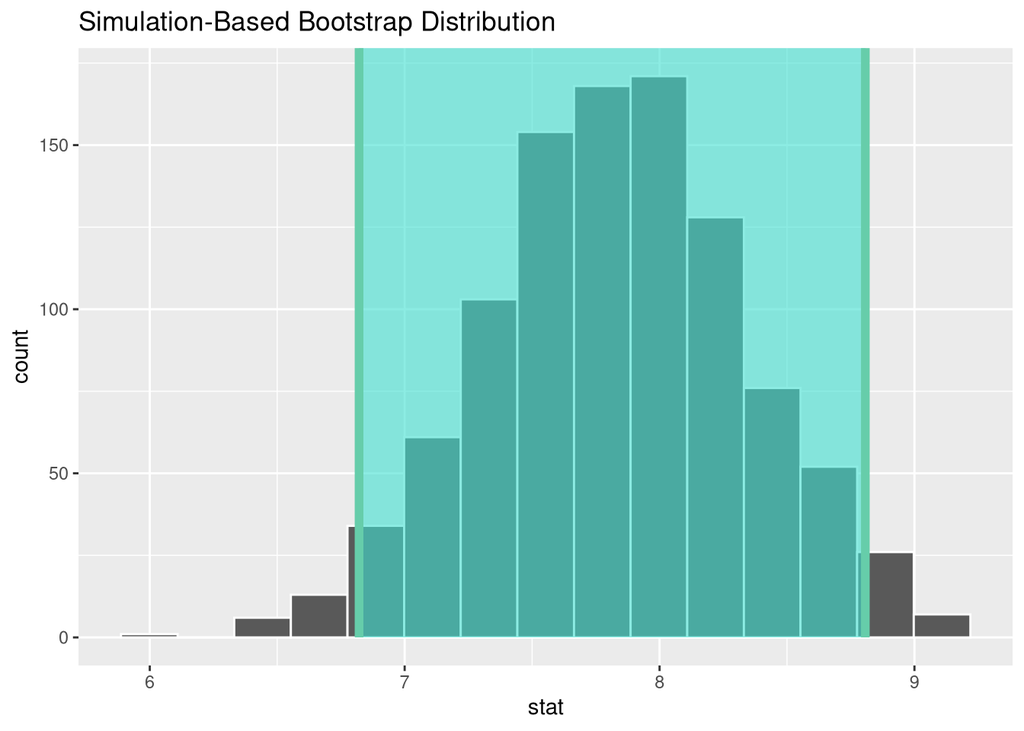

```r
visualize(avg_Temp_bootstrap) +
  shade_confidence_interval(endpoints = ci)
```

This histogram shows the distribution of average temperatures from 1000 samples using the bootstrapping method. This shows what we expect the average temperature to be if we randomly select a sample from our population.

```r
avg_Temp_CI <- avg_Temp_bootstrap %>%
  summarize(
    lower = quantile(stat, 0.025),
    upper = quantile(stat, 0.975)
  )

avg_Temp_CI
```

```
## # A tibble: 1 × 2
##   lower upper
##   <dbl> <dbl>
## 1  6.82  8.81
```

### **Hypothesis testing**

```r
summer_CO2 <- environmentalData %>%
  filter(Month %in% c(6, 7, 8)) %>%
  pull(CO2)

winter_CO2 <- environmentalData %>%
  filter(Month %in% c(12, 1, 2)) %>%
  pull(CO2)

t.test(summer_CO2, winter_CO2)
```

```
##
##  Welch Two Sample t-test
##
## data:  summer_CO2 and winter_CO2
## t = -0.53088, df = 273.98, p-value = 0.5959
## alternative hypothesis: true difference in means is not equal to 0
## 95 percent confidence interval:
##  -7.541515  4.338037
## sample estimates:
## mean of x mean of y
##  373.8858  375.4875
```

This t-test shows that there is no statistical different between the CO2 level in the summer and winter months. We se this because the p-value is greater than .05, so we fail to reject the null hypothesis. Another thing that tips us off is the fact that the 95% confidence interval includes 0.

```r
summer_temps <- environmentalData %>%
  filter(Month %in% c(6, 7, 8)) %>%
  pull(Average.Temp)

winter_temps <- environmentalData %>%
  filter(Month %in% c(12, 1, 2)) %>%
  pull(Average.Temp)

t.test(summer_temps, winter_temps)
```

```
##
##  Welch Two Sample t-test
##
## data:  summer_temps and winter_temps
## t = 82.684, df = 193.52, p-value < 2.2e-16
## alternative hypothesis: true difference in means is not equal to 0
## 95 percent confidence interval:
##  28.41336 29.80200
## sample estimates:
## mean of x mean of y
## 21.649130 -7.458551
```

From the two-sample t-test, we can see that there is a statistically significant difference between the average temperature of the summer months and the average temperature of the winter months. Since the p-value is less than .05, we reject the null hypothesis. The 95% confidence interval shows us that we are 95% confident that the average difference in temperatures is between 28.4 and 29.8 degrees Celsius.